# Covid Data Analysis

Catherine Haynes

2024-12-03

### Import libraries

Note: To knit, please make sure you have the following libraries installed:

- sp
- spdep
- tidyverse
- dplyr
- ggplot2
- ggmap

```r
library(tidyverse)
```

```r
library(dplyr)
library(ggplot2)
library(ggmap)
```

### Import the Covid Case Data

```r
covid_url <- "https://raw.githubusercontent.com/CSSEGISandData/COVID-19/refs/heads/master/csse_covid_19_data/csse_covid_19_time_series/time_series_covid19_confirmed_US.csv"
covid <- read_csv(covid_url)
```

This data contains case counts for the Covid-19 pandemic. These counts are reported by day and city.

### Preview the data

```r
head(covid, 10)
```

```
## # A tibble: 10 × 1,154
##         UID iso2  iso3  code3  FIPS Admin2   Province_State Country_Region   Lat
##       <dbl> <chr> <chr> <dbl> <dbl> <chr>    <chr>          <chr>          <dbl>
##  1 84001001 US    USA     840  1001 Autauga  Alabama        US              32.5
##  2 84001003 US    USA     840  1003 Baldwin  Alabama        US              30.7
##  3 84001005 US    USA     840  1005 Barbour  Alabama        US              31.9
##  4 84001007 US    USA     840  1007 Bibb     Alabama        US              33.0
##  5 84001009 US    USA     840  1009 Blount   Alabama        US              34.0
##  6 84001011 US    USA     840  1011 Bullock  Alabama        US              32.1
##  7 84001013 US    USA     840  1013 Butler   Alabama        US              31.8
##  8 84001015 US    USA     840  1015 Calhoun  Alabama        US              33.8
##  9 84001017 US    USA     840  1017 Chambers Alabama        US              32.9
## 10 84001019 US    USA     840  1019 Cherokee Alabama        US              34.2
## # ℹ 1,145 more variables: Long_ <dbl>, Combined_Key <chr>, `1/22/20` <dbl>,
## #   `1/23/20` <dbl>, `1/24/20` <dbl>, `1/25/20` <dbl>, `1/26/20` <dbl>,
## #   `1/27/20` <dbl>, `1/28/20` <dbl>, `1/29/20` <dbl>, `1/30/20` <dbl>,
## #   `1/31/20` <dbl>, `2/1/20` <dbl>, `2/2/20` <dbl>, `2/3/20` <dbl>,
## #   `2/4/20` <dbl>, `2/5/20` <dbl>, `2/6/20` <dbl>, `2/7/20` <dbl>,
## #   `2/8/20` <dbl>, `2/9/20` <dbl>, `2/10/20` <dbl>, `2/11/20` <dbl>,
## #   `2/12/20` <dbl>, `2/13/20` <dbl>, `2/14/20` <dbl>, `2/15/20` <dbl>, …
```

Each date is shown as its own column. We will pivot the table so that all dates are listed in one column and the values associated with them become a new column as well.

```r
covid_long <- pivot_longer(covid,
                           cols = -c('UID', 'iso2', 'iso3', 'code3', 'FIPS', 'Admin2', 'Province_State', 'Country_Region', 'Lat', 'Long_', 'Combined_Key'),
                           names_to = "Date",
                           values_to = "Count")

covid_long
```

```
## # A tibble: 3,819,906 × 13
##         UID iso2  iso3  code3  FIPS Admin2  Province_State Country_Region   Lat
##       <dbl> <chr> <chr> <dbl> <dbl> <chr>   <chr>          <chr>          <dbl>
##  1 84001001 US    USA     840  1001 Autauga Alabama        US              32.5
##  2 84001001 US    USA     840  1001 Autauga Alabama        US              32.5
##  3 84001001 US    USA     840  1001 Autauga Alabama        US              32.5
##  4 84001001 US    USA     840  1001 Autauga Alabama        US              32.5
##  5 84001001 US    USA     840  1001 Autauga Alabama        US              32.5
##  6 84001001 US    USA     840  1001 Autauga Alabama        US              32.5
##  7 84001001 US    USA     840  1001 Autauga Alabama        US              32.5
##  8 84001001 US    USA     840  1001 Autauga Alabama        US              32.5
##  9 84001001 US    USA     840  1001 Autauga Alabama        US              32.5
## 10 84001001 US    USA     840  1001 Autauga Alabama        US              32.5
## # ℹ 3,819,896 more rows
## # ℹ 4 more variables: Long_ <dbl>, Combined_Key <chr>, Date <chr>, Count <dbl>
```

### Update and Remove Uneeded Columns

[output not shown]

```r
#remove unwanted columns
covid_long <- covid_long %>%
  select(-c('UID', 'iso2', 'iso3', 'code3', 'FIPS'))
```

```r
#update data types
covid_long$Date <- as.Date(covid_long$Date, format = "%m/%d/%y")

summary(covid_long)
```

```
##     Admin2          Province_State     Country_Region          Lat
##  Length:3819906     Length:3819906     Length:3819906     Min.   :-14.27
##  Class :character   Class :character   Class :character   1st Qu.: 33.90
##  Mode  :character   Mode  :character   Mode  :character   Median : 38.01
##                                                           Mean   : 36.72
##                                                           3rd Qu.: 41.58
##                                                           Max.   : 69.31
##      Long_         Combined_Key            Date                Count
##  Min.   :-174.16   Length:3819906     Min.   :2020-01-22   Min.   :  -3073
##  1st Qu.: -97.81   Class :character   1st Qu.:2020-11-02   1st Qu.:    330
##  Median : -89.49   Mode  :character   Median :2021-08-15   Median :   2272
##  Mean   : -88.64                      Mean   :2021-08-15   Mean   :  14088
##  3rd Qu.: -82.31                      3rd Qu.:2022-05-28   3rd Qu.:   8159
##  Max.   : 145.67                      Max.   :2023-03-09   Max.   :3710586
```

### Question of Interest

Are there seasonal trends in Covid-19 cases? We will use data between 1-22-2020 - 1-8-2023 so that we are looking at three complete years.

```r
#Remove dates after 1-8-2023 so we have 3 complete years of data
cutoff_date <- as.Date("2023-01-08")
covid_3years <- covid_long[covid_long$Date <= cutoff_date, ]

summary(covid_3years)
```

```
##     Admin2          Province_State     Country_Region          Lat
##  Length:3619386     Length:3619386     Length:3619386     Min.   :-14.27
##  Class :character   Class :character   Class :character   1st Qu.: 33.90
##  Mode  :character   Mode  :character   Mode  :character   Median : 38.01
##                                                           Mean   : 36.72
##                                                           3rd Qu.: 41.58
##                                                           Max.   : 69.31
##      Long_         Combined_Key            Date                Count
##  Min.   :-174.16   Length:3619386     Min.   :2020-01-22   Min.   :  -3073
##  1st Qu.: -97.81   Class :character   1st Qu.:2020-10-18   1st Qu.:    283
##  Median : -89.49   Mode  :character   Median :2021-07-16   Median :   2089
##  Mean   : -88.64                      Mean   :2021-07-16   Mean   :  13166
##  3rd Qu.: -82.31                      3rd Qu.:2022-04-13   3rd Qu.:   7555
##  Max.   : 145.67                      Max.   :2023-01-08   Max.   :3646917
```

```r
#create a season column

covid_3years <- covid_3years %>%
  mutate(Season = case_when(
    Date >= as.Date(paste(year(Date), 3, 20, sep = "-")) & Date < as.Date(paste(year(Date), 6, 21, sep = "-")) ~ "Spring",
    Date >= as.Date(paste(year(Date), 6, 21, sep = "-")) & Date < as.Date(paste(year(Date), 9, 23, sep = "-")) ~ "Summer",
    Date >= as.Date(paste(year(Date), 9, 23, sep = "-")) & Date < as.Date(paste(year(Date), 12, 21, sep = "-")) ~ "Fall",
    TRUE ~ "Winter"
  ))

print(covid_3years)
```

```
## # A tibble: 3,619,386 × 9
##    Admin2  Province_State Country_Region   Lat Long_ Combined_Key     Date
##    <chr>   <chr>          <chr>          <dbl> <dbl> <chr>            <date>
##  1 Autauga Alabama        US              32.5 -86.6 Autauga, Alabam… 2020-01-22
##  2 Autauga Alabama        US              32.5 -86.6 Autauga, Alabam… 2020-01-23
##  3 Autauga Alabama        US              32.5 -86.6 Autauga, Alabam… 2020-01-24
##  4 Autauga Alabama        US              32.5 -86.6 Autauga, Alabam… 2020-01-25
##  5 Autauga Alabama        US              32.5 -86.6 Autauga, Alabam… 2020-01-26
##  6 Autauga Alabama        US              32.5 -86.6 Autauga, Alabam… 2020-01-27
##  7 Autauga Alabama        US              32.5 -86.6 Autauga, Alabam… 2020-01-28
##  8 Autauga Alabama        US              32.5 -86.6 Autauga, Alabam… 2020-01-29
##  9 Autauga Alabama        US              32.5 -86.6 Autauga, Alabam… 2020-01-30
## 10 Autauga Alabama        US              32.5 -86.6 Autauga, Alabam… 2020-01-31
## # ℹ 3,619,376 more rows
## # ℹ 2 more variables: Count <dbl>, Season <chr>
```

```r
#create new column for new cases by day

covid_3years <- covid_3years %>%
  group_by(Combined_Key) %>%
  arrange(Date) %>%
  mutate(New_Cases = Count - lag(Count, default = 0)) %>%
  ungroup()

print(covid_3years)
```

```
## # A tibble: 3,619,386 × 10
##    Admin2   Province_State Country_Region   Lat Long_ Combined_Key    Date
##    <chr>    <chr>          <chr>          <dbl> <dbl> <chr>           <date>
##  1 Autauga  Alabama        US              32.5 -86.6 Autauga, Alaba… 2020-01-22
##  2 Baldwin  Alabama        US              30.7 -87.7 Baldwin, Alaba… 2020-01-22
##  3 Barbour  Alabama        US              31.9 -85.4 Barbour, Alaba… 2020-01-22
##  4 Bibb     Alabama        US              33.0 -87.1 Bibb, Alabama,… 2020-01-22
##  5 Blount   Alabama        US              34.0 -86.6 Blount, Alabam… 2020-01-22
##  6 Bullock  Alabama        US              32.1 -85.7 Bullock, Alaba… 2020-01-22
##  7 Butler   Alabama        US              31.8 -86.7 Butler, Alabam… 2020-01-22
##  8 Calhoun  Alabama        US              33.8 -85.8 Calhoun, Alaba… 2020-01-22
##  9 Chambers Alabama        US              32.9 -85.4 Chambers, Alab… 2020-01-22
## 10 Cherokee Alabama        US              34.2 -85.6 Cherokee, Alab… 2020-01-22
## # ℹ 3,619,376 more rows
## # ℹ 3 more variables: Count <dbl>, Season <chr>, New_Cases <dbl>
```

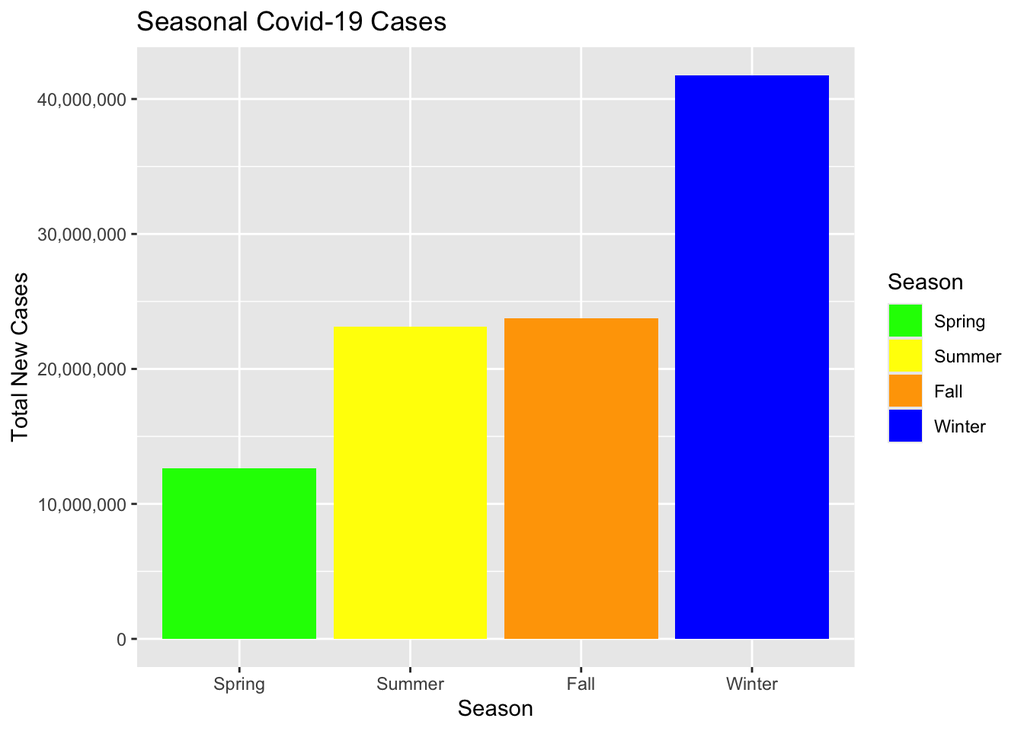

```r
#create a bar graph that show total cases by season
season_summary <- covid_3years %>%
  group_by(Season) %>%
  summarize(Total_New_Cases = sum(New_Cases, na.rm = TRUE))

#set order of seasons
season_summary$Season <- factor(season_summary$Season,
                                levels = c("Spring", "Summer", "Fall", "Winter"))

ggplot(data = season_summary, aes(x=Season, y= Total_New_Cases, fill=Season)) +
  geom_bar(stat = "identity") +
  scale_y_continuous(labels = scales::comma) +
  labs(title = "Seasonal Covid-19 Cases", x = "Season", y= "Total New Cases")+
  scale_fill_manual(values = c("Spring" = "green", "Summer" = "yellow", "Fall" = "orange", "Winter" = "blue"))
```

Including three years of data, Winter showed the highest total of cases. Spring showed the fewest total cases.

### Prevelance of Cases by Season and Location

By season, we are now going to look at the prevalence of cases in different locations in the continental US.

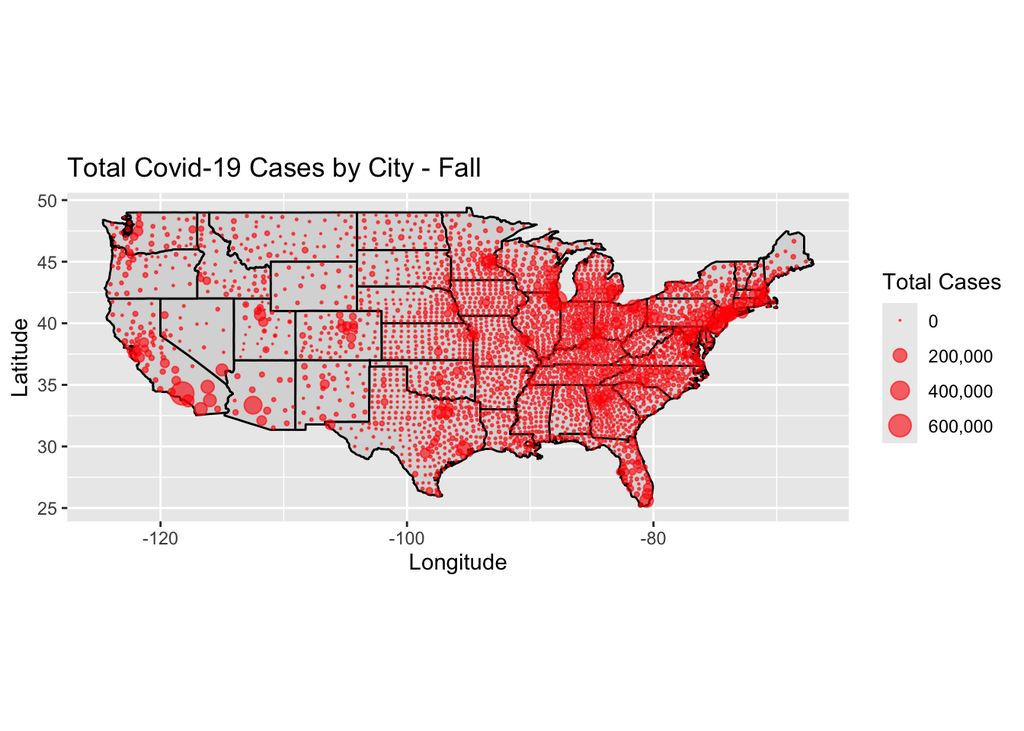

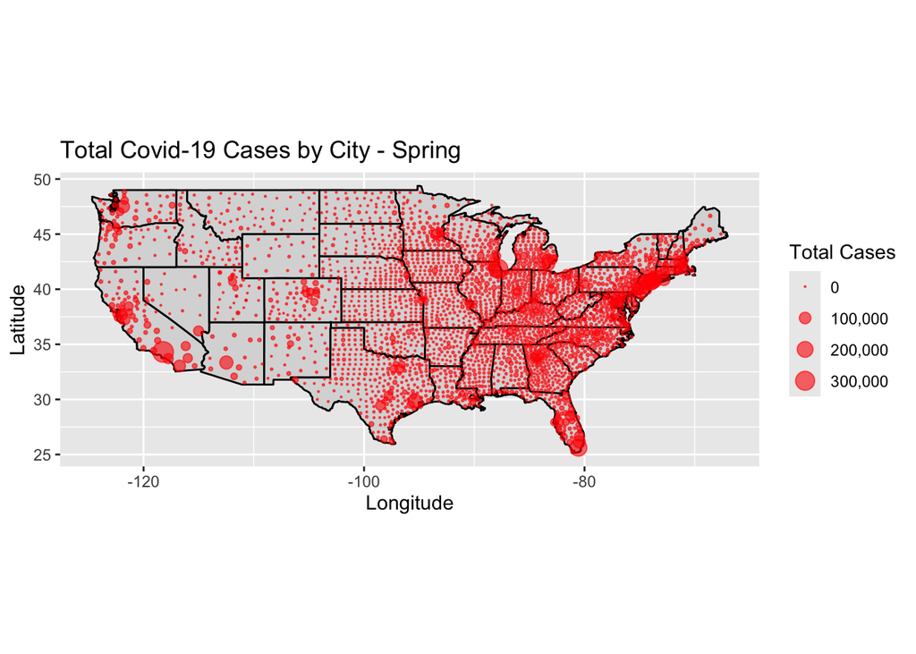

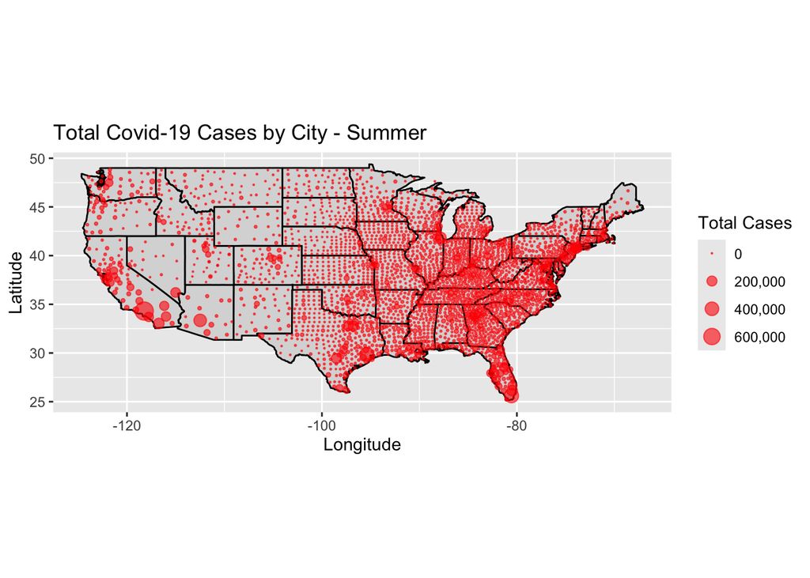

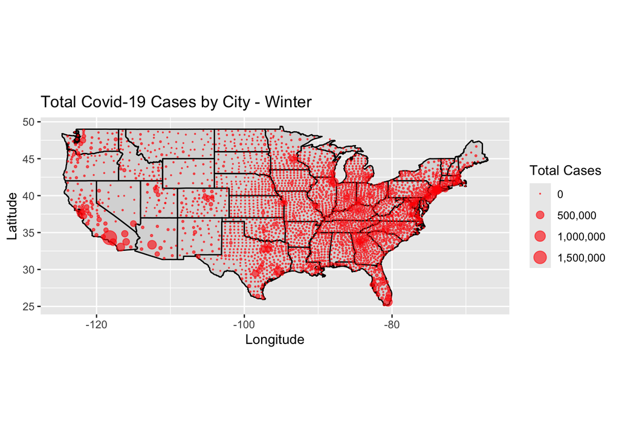

```r
filtered_lat <- covid_3years %>%
  filter(Long_ <-65 & Long_ >-130 , Lat >24 & Lat <50)

city_summary <- filtered_lat %>%
  group_by(Admin2, Province_State, Lat, Long_, Season) %>%
  summarize(Total_New_Cases = sum(New_Cases, na.rm = TRUE), .groups = 'drop')

us_map <- map_data("state")

seasons <- unique(city_summary$Season)

for (season in seasons) {
  season_data <- city_summary %>%
    filter(Season == season)

  ggplot() +
    geom_polygon(data = us_map, aes(x= long, y= lat, group = group), fill = 'grey85', color = 'black') +
    geom_point(data = season_data, aes(x=Long_, y=Lat, size = Total_New_Cases, color = Total_New_Cases), color = "red", alpha = 0.6) +
    scale_size_continuous(name = "Total Cases", range = c(0.05,5), labels=scales::comma) +
    labs(title = paste("Total Covid-19 Cases by City -", season), x="Longitude", y = "Latitude") +
    theme(legend.position = "right") +
    coord_fixed()

  print(last_plot())
}
```

Most cities follow the same trends we saw cumulatively- the number of cases are smallest in spring compared to the other three seasons.

### Model and Analysis Using Moran’s I

```r
library(sp)
library(spdep)
for (season in unique(city_summary$Season)) {

  season_groups <- city_summary %>%
    filter(Season == season)

  coordinates(season_groups) <- ~ Long_ + Lat

  neighbors <- knn2nb(knearneigh(coordinates(season_groups), k=4))

  listw <- nb2listw(neighbors, style = "W")

  cases <- season_groups$Total_New_Cases

  moran_test <- moran.test(cases, listw)

  cat(paste("Moran's I Test for", season, "\n"))
  print(moran_test)
  cat("\n")
}
```

```
## Moran's I Test for Fall
##
##  Moran I test under randomisation
##
## data:  cases
## weights: listw
##
## Moran I statistic standard deviate = 30.164, p-value < 2.2e-16
## alternative hypothesis: greater
## sample estimates:
## Moran I statistic       Expectation          Variance
##      0.3487253034     -0.0003210273      0.0001338986
```

```
## Moran's I Test for Spring
##
##  Moran I test under randomisation
##
## data:  cases
## weights: listw
##
## Moran I statistic standard deviate = 36.272, p-value < 2.2e-16
## alternative hypothesis: greater
## sample estimates:
## Moran I statistic       Expectation          Variance
##      0.4259583555     -0.0003210273      0.0001381191
```

```
## Moran's I Test for Summer
##
##  Moran I test under randomisation
##
## data:  cases
## weights: listw
##
## Moran I statistic standard deviate = 28.139, p-value < 2.2e-16
## alternative hypothesis: greater
## sample estimates:
## Moran I statistic       Expectation          Variance
##      0.3223355072     -0.0003210273      0.0001314852
```

```
## Moran's I Test for Winter
##
##  Moran I test under randomisation
##
## data:  cases
## weights: listw
##
## Moran I statistic standard deviate = 30.617, p-value < 2.2e-16
## alternative hypothesis: greater
## sample estimates:
## Moran I statistic       Expectation          Variance
##      0.3322849865     -0.0003210273      0.0001180127
```

All positive Moran 1 Statistics indicate that there is a tendency for cases to group together spatially. So, if a city has a high number of cases, it is also likely for surrounding areas to have high numbers. This is most true in Spring, then Fall, Winter, and finally, Summer.

### Conclusion and Bias

There is potential for bias in Covid data because the analysis only covers reported cases. There are a large number of cases that were never reported and some populations of people that are underrepresented in the data, like rural communities. This can impact our analysis, but our findings likely represent the change in cases by season accurately because cases were likely underreportted in all seasons.